# PML Course Project

Emiel Schoenmakers

March 24th, 2016

## Summary

Personal tracking devices generate data about daily movement patterns. The amount of movement is not an indicator how effective an exercise is executed. In the experiment data is collected on six persons to see how well (measured in five classes, 1 correctly and 4 different incorrect) they executed a particular exercise with a dumbbell.

## Data

The data for this assignment originates from (http://groupware.les.inf.puc-rio.br/har), thanks!

### Load Data

```r
urlTest <-"https://d396qusza40orc.cloudfront.net/predmachlearn/pml-testing.csv"
urlTrain<-"https://d396qusza40orc.cloudfront.net/predmachlearn/pml-training.csv"
trainObs <- read.csv(urlTrain, na.strings = c("#DIV/0!","NA",""))
validObs <- read.csv(urlTest,na.strings = c("#DIV/0!","NA",""))
str(trainObs[,1:25]) # only first 25 comlumns shown
```

```
## 'data.frame':    19622 obs. of  25 variables:
##  $ X                   : int  1 2 3 4 5 6 7 8 9 10 ...
##  $ user_name           : Factor w/ 6 levels "adelmo","carlitos",..: 2 2 2 2 2 2 2 2 2 2 ...
##  $ raw_timestamp_part_1: int  1323084231 1323084231 1323084231 1323084232 1323084232 1323084232 1323084232 1323084232 1323084232 1323084232 ...
##  $ raw_timestamp_part_2: int  788290 808298 820366 120339 196328 304277 368296 440390 484323 484434 ...
##  $ cvtd_timestamp      : Factor w/ 20 levels "02/12/2011 13:32",..: 9 9 9 9 9 9 9 9 9 9 ...
##  $ new_window          : Factor w/ 2 levels "no","yes": 1 1 1 1 1 1 1 1 1 1 ...
##  $ num_window          : int  11 11 11 12 12 12 12 12 12 12 ...
##  $ roll_belt           : num  1.41 1.41 1.42 1.48 1.48 1.45 1.42 1.42 1.43 1.45 ...
##  $ pitch_belt          : num  8.07 8.07 8.07 8.05 8.07 8.06 8.09 8.13 8.16 8.17 ...
##  $ yaw_belt            : num  -94.4 -94.4 -94.4 -94.4 -94.4 -94.4 -94.4 -94.4 -94.4 -94.4 ...
##  $ total_accel_belt    : int  3 3 3 3 3 3 3 3 3 3 ...
##  $ kurtosis_roll_belt  : num  NA NA NA NA NA NA NA NA NA NA ...
##  $ kurtosis_picth_belt : num  NA NA NA NA NA NA NA NA NA NA ...
##  $ kurtosis_yaw_belt   : logi  NA NA NA NA NA NA ...
##  $ skewness_roll_belt  : num  NA NA NA NA NA NA NA NA NA NA ...
##  $ skewness_roll_belt.1: num  NA NA NA NA NA NA NA NA NA NA ...
##  $ skewness_yaw_belt   : logi  NA NA NA NA NA NA ...
##  $ max_roll_belt       : num  NA NA NA NA NA NA NA NA NA NA ...
##  $ max_picth_belt      : int  NA NA NA NA NA NA NA NA NA NA ...
##  $ max_yaw_belt        : num  NA NA NA NA NA NA NA NA NA NA ...
##  $ min_roll_belt       : num  NA NA NA NA NA NA NA NA NA NA ...
##  $ min_pitch_belt      : int  NA NA NA NA NA NA NA NA NA NA ...
##  $ min_yaw_belt        : num  NA NA NA NA NA NA NA NA NA NA ...
##  $ amplitude_roll_belt : num  NA NA NA NA NA NA NA NA NA NA ...
##  $ amplitude_pitch_belt: int  NA NA NA NA NA NA NA NA NA NA ...
```

### Explore and Preproces Data

A brief look learns that the data contains a number of NA’s and an interesting ‘new_window’ column. Looking at the provided information [study para 5.1](http://groupware.les.inf.puc-rio.br/public/papers/2013.Velloso.QAR-WLE.pdf)

First we drop the new_window = yes; these lines contain aggregates. Next we identify and remove near zero values (columns). Third, columns 1-6 contain no observations (but metadata), not used in model. Finally we remove columns with a correlation > 0.9 This results in a data set for model development and testing; the imported ‘test’ set is used for validation (the quiz) only.

```r
trainObs <- subset(trainObs, new_window == "no") #drops 406
#detect near zero values
nzvTrain <- nearZeroVar(trainObs, saveMetrics = FALSE)
trainObs <- trainObs[,-nzvTrain] # drop nzv from training
myValid <- validObs[,-nzvTrain] # drop nzv from validObs, to keep eval and training similar
#remove first six columns (none observations to be used for prediction)
trainObs <- trainObs[7:59]
myValid <- myValid[7:59]
#remove high Correlated columns (cutoff default = 0.90)
dfCorr <- cor(subset(trainObs, select = - classe))
highCorr <- findCorrelation(dfCorr)
trainObs <- trainObs[,-highCorr]
myValid <- myValid[,-highCorr]
```

### Prepare datasets

For the cross validation I split the data set (trainObs) 60/40 in a training ans a test set

```r
set.seed(53124)
inTrain <- createDataPartition(y=trainObs$classe, p=0.6,list = FALSE)
myTrain <- trainObs[inTrain,]
myTest <- trainObs[-inTrain,]
```

## Machine Learning Model selection

Using the training set I tried to predict the test set using two models: random forest and tree. I gave up the attempt to use different models (eg LDA and GLM) because of the huge running times. RF completed in about three minutes on my PC, both LDA and GLM ran for more than an hour before I broke off the calculations.

```r
modRF <- randomForest(classe~., data = myTrain)
modTree <- train(classe~., data = myTrain, method = "rpart")
modRF
```

```
##
## Call:
##  randomForest(formula = classe ~ ., data = myTrain)
##                Type of random forest: classification
##                      Number of trees: 500
## No. of variables tried at each split: 6
##
##         OOB estimate of  error rate: 0.74%
## Confusion matrix:
##      A    B    C    D    E  class.error
## A 3280    3    0    0    0 0.0009137984
## B   15 2207    9    0    0 0.0107575078
## C    0   17 1991    4    0 0.0104373757
## D    0    0   25 1859    5 0.0158814187
## E    0    0    1    6 2110 0.0033065659
```

```r
modTree
```

```
## CART
##
## 11532 samples
##    45 predictor
##     5 classes: 'A', 'B', 'C', 'D', 'E'
##
## No pre-processing
## Resampling: Bootstrapped (25 reps)
## Summary of sample sizes: 11532, 11532, 11532, 11532, 11532, 11532, ...
## Resampling results across tuning parameters:
##
##   cp          Accuracy   Kappa      Accuracy SD  Kappa SD
##   0.03006425  0.5245572  0.3887402  0.02960141   0.04643166
##   0.03418596  0.5080601  0.3669401  0.03635676   0.05738191
##   0.06731119  0.3516039  0.1119388  0.09289604   0.15238505
##
## Accuracy was used to select the optimal model using  the largest value.
## The final value used for the model was cp = 0.03006425.
```

## Accuracy Final Model

Using both models we compare the predicted class (outXX) with the actual classe using the confusionmatrix function.

```r
outRF <- predict(modRF, newdata = myTest)
outTree <- predict(modTree, newdata = myTest)
confusionMatrix(outRF, myTest$classe)$overall['Accuracy']
```

```
##  Accuracy
## 0.9923217
```

```r
confusionMatrix(outTree, myTest$classe)$overall['Accuracy']
```

```
##  Accuracy
## 0.4908902
```

Comparing both Accuracies, the Random Forest is the better of the two and gives a quite high accuracy (>>95%)

Exploring this model further we look at the complete confusion matrix and look at which variables are most important for the prediction

```r
confusionMatrix(outRF, myTest$classe)
```

```
## Confusion Matrix and Statistics
##
##           Reference
## Prediction    A    B    C    D    E
##          A 2181   15    0    0    0
##          B    3 1470   11    0    0
##          C    0    2 1327   18    2
##          D    0    0    2 1239    1
##          E    4    0    0    1 1408
##
## Overall Statistics
##
##                Accuracy : 0.9923
##                  95% CI : (0.9901, 0.9941)
##     No Information Rate : 0.2847
##     P-Value [Acc > NIR] : < 2.2e-16
##
##                   Kappa : 0.9903
##  Mcnemar's Test P-Value : NA
##
## Statistics by Class:
##
##                      Class: A Class: B Class: C Class: D Class: E
## Sensitivity            0.9968   0.9886   0.9903   0.9849   0.9979
## Specificity            0.9973   0.9977   0.9965   0.9995   0.9992
## Pos Pred Value         0.9932   0.9906   0.9837   0.9976   0.9965
## Neg Pred Value         0.9987   0.9973   0.9979   0.9971   0.9995
## Prevalence             0.2847   0.1935   0.1744   0.1637   0.1836
## Detection Rate         0.2838   0.1913   0.1727   0.1612   0.1832
## Detection Prevalence   0.2858   0.1931   0.1756   0.1616   0.1839
## Balanced Accuracy      0.9970   0.9932   0.9934   0.9922   0.9985
```

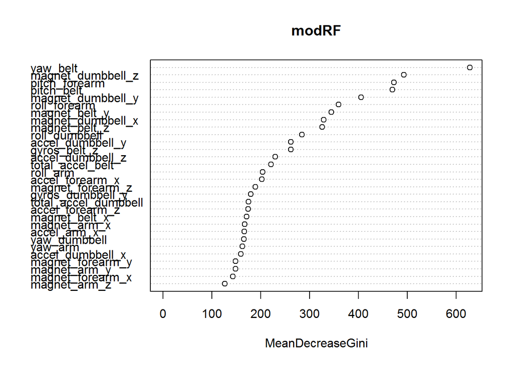

```r
varImpPlot(modRF)
```

## Results for Validation Set - the Quiz..

Finally we look at the provided validation data (pml-testing). This is also the data used in the quiz for the assignment

```r
outValid <- predict(modRF, newdata = myValid)
outValid
```

```
##  1  2  3  4  5  6  7  8  9 10 11 12 13 14 15 16 17 18 19 20
##  B  A  B  A  A  E  D  B  A  A  B  C  B  A  E  E  A  B  B  B
## Levels: A B C D E
```